# Linear Model & Regularization

1. In this exercise, we will predict the number of applications received using the other variables in the College data set.
1. Split the data set into a training set and a test set.

```r
library(ISLR)
attach(College)

head(College)
```

|  | Private | Apps | Accept | Enroll | Top10perc | Top25perc | F.Undergrad | P.Undergrad | Outstate | Room.Board | Books | Personal | PhD | Terminal | S.F.Ratio | perc.alumni | Expend | Grad.Rate |
| --- | --- | --- | --- | --- | --- | --- | --- | --- | --- | --- | --- | --- | --- | --- | --- | --- | --- | --- |
| Abilene Christian University | Yes | 1660 | 1232 | 721 | 23 | 52 | 2885 | 537 | 7440 | 3300 | 450 | 2200 | 70 | 78 | 18.1 | 12 | 7041 | 60 |
| Adelphi University | Yes | 2186 | 1924 | 512 | 16 | 29 | 2683 | 1227 | 12280 | 6450 | 750 | 1500 | 29 | 30 | 12.2 | 16 | 10527 | 56 |
| Adrian College | Yes | 1428 | 1097 | 336 | 22 | 50 | 1036 | 99 | 11250 | 3750 | 400 | 1165 | 53 | 66 | 12.9 | 30 | 8735 | 54 |
| Agnes Scott College | Yes | 417 | 349 | 137 | 60 | 89 | 510 | 63 | 12960 | 5450 | 450 | 875 | 92 | 97 | 7.7 | 37 | 19016 | 59 |
| Alaska Pacific University | Yes | 193 | 146 | 55 | 16 | 44 | 249 | 869 | 7560 | 4120 | 800 | 1500 | 76 | 72 | 11.9 | 2 | 10922 | 15 |
| Albertson College | Yes | 587 | 479 | 158 | 38 | 62 | 678 | 41 | 13500 | 3335 | 500 | 675 | 67 | 73 | 9.4 | 11 | 9727 | 55 |

```r
set.seed(1)


train = sample(dim(College)[1], size = 0.50*dim(College)[1], replace=FALSE) # set 50% of data set as training set
test = -train               # set remaining 50% of data set as tesr set

training.set = College[train, ]     # split training set
test.set= College[test, ]       # split test set

dim(College) # entire data set
```

```
[1] 777  18
```

```r
dim(test.set) # Validation set
```

```
[1] 389  18
```

2. Fit a linear model using least-squares on the training set, and report the test error obtained.

```r
fit.lm = lm(Apps~., data=training.set) # fit linear model on training set using least squares
pred.lm = predict(fit.lm, test.set) # make prediction on test set
error.lm = mean((test.set$Apps - pred.lm)^2) # calculate test error using Mean Squared Error
error.lm
```

```
[1] 1135758
```

```r
rmse.lm = sqrt(error.lm) # find RMSE of predictions
rmse.lm
```

```
[1] 1065.72
```

3. Fit a ridge regression model on the training set, with λ chosen by cross-validation. Report the test error obtained.

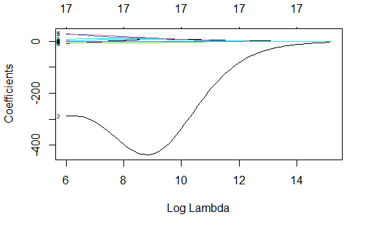

```r
library(glmnet) # package does not use model formula language
x.train = model.matrix(Apps~., data=training.set) # set up x.train (predictors)
y.train = training.set$Apps # set up y.train (response)
x.test = model.matrix(Apps~., data=test.set) # set up x (predictors)
y.test = test.set$Apps

# model selection using ridge regression
fit.ridge = glmnet(x.train, y.train, alpha=0) # fit ridge regression
plot(fit.ridge, xvar="lambda", label=TRUE) # plot coefficients of the predictors; recall that the ridge regressions model is penalized by the sum of squares of the coefficients multiplied by lambda
```

```r
cv.ridge = cv.glmnet(x.train, y.train, alpha=0) # "cv.glmnet" is a built-in function used to perform cross-validation, with k=10 as default
cv.ridge
```

```
Call:  cv.glmnet(x = x.train, y = y.train, alpha = 0)

Measure: Mean-Squared Error

    Lambda Index Measure      SE Nonzero
min  405.8   100 2162007 1039176      17
1se 1798.1    84 3121770 1682760      17
```

```r
bestlambda = cv.ridge$lambda.min # select minimum lambda model
pred.ridge = predict(fit.ridge, s=bestlambda, newx=x.test)

error.ridge = mean((y.test - pred.ridge)^2)
error.ridge
```

```
[1] 976261.5
```

```r
rmse.ridge = sqrt(error.ridge)  # find RMSE of ridge regression model
rmse.ridge
```

```
[1] 988.0595
```

4. Fit a lasso model on the training set, with λ chosen by cross-validation. Report the test error obtained, along with the number of non-zero coefficient estimates.

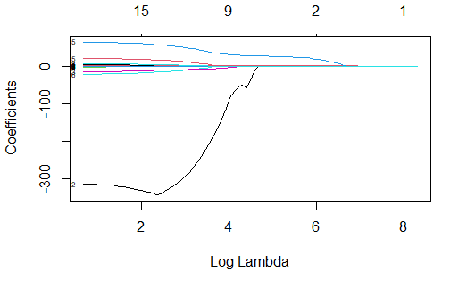

```r
fit.lasso = glmnet(x.train, y.train, alpha=1) # fit lasso model
plot(fit.lasso, xvar="lambda", label=TRUE) # plot coefficients of the predictors; recall that the ridge regressions model is penalized by the sum of squares of the coefficients multiplied by lambda
```

```r
cv.lasso = cv.glmnet(x.train, y.train, alpha=1) # "cv.glmnet" is a built-in function used to perform cross-validation, with k=10 as default
cv.lasso
```

```
Call:  cv.glmnet(x = x.train, y = y.train, alpha = 1)

Measure: Mean-Squared Error

    Lambda Index Measure     SE Nonzero
min    2.0    83 1618133 457125      17
1se  477.6    24 2071673 749608       2
```

```r
bestlambda = cv.lasso$lambda.min # choose minimum lambda model

pred.lasso = predict(fit.lasso, s=bestlambda, newx=x.test)

error.lasso = mean((y.test - pred.ridge)^2)
error.lasso
```

```
[1] 976261.5
```

```r
rmse.lasso = sqrt(error.lasso)  # find RMSE of lasso model
rmse.lasso
```

```
[1] 988.0595
```

```r
coef(fit.lasso, s=bestlambda) # show the number of non-zero coefficient estimates
```

```
19 x 1 sparse Matrix of class "dgCMatrix"
                       s1
(Intercept) -7.688896e+02
(Intercept)  .
PrivateYes  -3.127034e+02
Accept       1.762718e+00
Enroll      -1.318195e+00
Top10perc    6.482356e+01
Top25perc   -2.081406e+01
F.Undergrad  7.119149e-02
P.Undergrad  1.246161e-02
Outstate    -1.049091e-01
Room.Board   2.088305e-01
Books        2.926466e-01
Personal     3.955068e-03
PhD         -1.455463e+01
Terminal     5.395858e+00
S.F.Ratio    2.171398e+01
perc.alumni  5.088260e-01
Expend       4.824455e-02
Grad.Rate    7.036148e+00
```

```r
predict(fit.lasso, s = bestlambda, type = "coefficients")
```

```
19 x 1 sparse Matrix of class "dgCMatrix"
                       s1
(Intercept) -7.688896e+02
(Intercept)  .
PrivateYes  -3.127034e+02
Accept       1.762718e+00
Enroll      -1.318195e+00
Top10perc    6.482356e+01
Top25perc   -2.081406e+01
F.Undergrad  7.119149e-02
P.Undergrad  1.246161e-02
Outstate    -1.049091e-01
Room.Board   2.088305e-01
Books        2.926466e-01
Personal     3.955068e-03
PhD         -1.455463e+01
Terminal     5.395858e+00
S.F.Ratio    2.171398e+01
perc.alumni  5.088260e-01
Expend       4.824455e-02
Grad.Rate    7.036148e+00
```